```python
import numpy as np
import matplotlib.pyplot as plt
%matplotlib notebook
```

# Assignment 4 Key

Consider flow over an isolated obstacle in a channel, as in class. Assume that the obstacle is a triangle, with height off a flat channel of $h_m = 10\ \mathrm{m}$, and that the triangle's ramp has a slope of 1/100. Assume that the incoming two-d flow transport is a fixed $30\ \mathrm{m^2\,s^{-1}}$, that the flow is in steady state, and that the flow is controlled at the crest.

## Q1

What is the thickness of the water column, $d_0$, far upstream of the obstacle? (OK to use a root finder and give a numeric answer)

```python
# Soe variables:

hm = 10 # m
q = 30 # m^2/s
g = 9.8
dhdx = 0.01 # i.e the bump is 1000 m long, 10 m hight
```

## A1

If transcritical then $$ \frac{1}{2} F_0^2 + 1 -\frac{3}{2}F_0^{2/3} = \frac{h_m}{d_0}$$

or in terms of $q$ we get a cubic for $d_o$:

```python
coef = [1., -3/2*q**(2/3)/g**(1/3) - hm, 0, q**2/2/g]
roots = np.roots(coef)
print(roots)
print(q**2/g/roots**3)
d0 = max(roots)
print('d0 = ',d0, 'm')
```

```
[ 16.60090986   1.7485285   -1.58191022]
[  2.00733917e-02   1.71790161e+01  -2.31990895e+01]
d0 =  16.6009098571 m
```

Note that there are two positive roots to this equation: one is for very thin very fast flow that is just transcritical, and one is for very thick slow flow. Lets choose the latter.

So $d_0 = 16.6 \ \mathrm{m}$

## Q2:

Knowing the height far upstream you can numerically integrate in x (or calculate the cubic at each point in x) to get the water thickness $d(x)$ as a function of $x$. Plot the water thickness as a function of $x$ from $x=-1000 m$ (upstream) to $x=0\ \mathrm{m}$ (the crest). Check that $F_m = 1$ in your calculation. For precision, make sure that you have a data point every 10 cm or so; include your code, and the expressions you used to get the interface heights. Make the plot as nice as possible (including the obstacle, helps.

## A2:

Now lets integrate:

$$ \frac{\partial d}{\partial x} = \left(F^2 - 1 \right)^{-1}\frac{\partial h}{\partial x}$$

```python
dx = 0.01
x = np.linspace(-1000.,0., int(1000/dx))

# init array
d = 0. * x
Fsq = 0. * x
h = 0. * x
d[0] = d0
Fsq[0] = q**2 / g / d0**3
h[0] = 0
for i in range(1,len(x)):
    d[i] = dhdx/(Fsq[i-1] - 1)*dx + d[i-1]
    Fsq[i] = q**2 / g / d[i]**3
    h[i] = dhdx * dx + h[i-1]

u = np.sqrt(Fsq*g*d)

print(h[-1])
um = (g*q)**(1/3)
print('u', u[-1], um)
dm = q / um
print('dm', d[-1], dm)
```

```
9.99989999999
u 6.60569378079 6.649399761150975
dm 4.54153658882 4.511685426897414
```

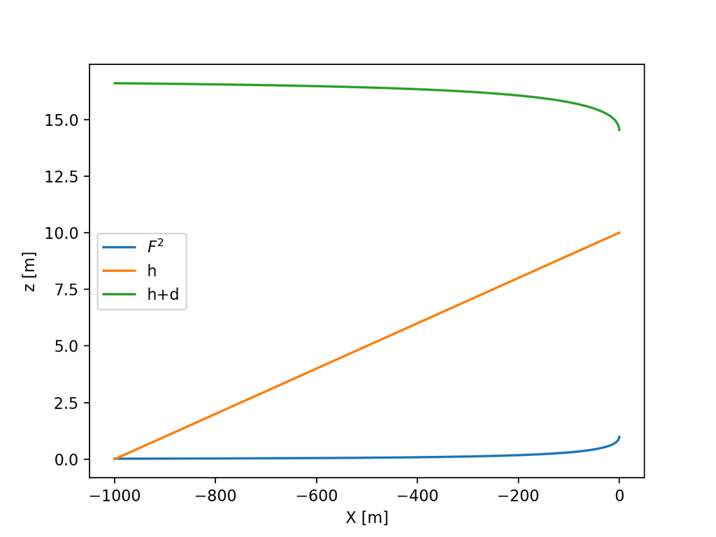

```
0.980410562441
```

```python
fig,ax = plt.subplots()
ax.plot(x, Fsq, label='$F^2$')
ax.plot(x, h, label='h')
ax.plot(x, h+d, label='h+d')
ax.set_xlabel('X [m]')
ax.set_ylabel('z [m]')
ax.legend()
print(Fsq[-1])
```

## Q3

Knowing the water thickness as a function of $x$, use the Momentum Theorem to numerically demonstrate that the momentum balance is satisfied.

## A3

Evaluating the momentum theorem for this volume we get that the net flux of moentum is equal to the net forces on the volume:

$$ u_0^2d_0 + \frac{g}{2}d_0^2 - u_m^2 d_m - \frac{g}{2} d_m^2 - g \frac{dh}{dx}\int_0^L d \ \mathrm{dx} = 0$$

where the last term is due to the form drag of the ramp.

```python
print(u[-1]**2 * d[-1])
print(g/2*d[0]**2 )
print(g/2*d[-1]**2 )
print('LHS:')
print(u[0]**2 * d[0] + g/2 * d[0]**2 - u[-1]**2 * d[-1] - g/2 * d[-1]**2)
print('RHS:')
print(g*dhdx*np.trapz(d, x))
```

```
198.170813424
1350.39201961
101.065217479
LHS:
1105.36988468
RHS:
1105.39092161
```

So the left hand and right hand sides are equal, so the momentum theorem is satisfied.